# Solutions to Hadley Wickham’s ggplot2: Elegant graphics for Data Analysis 2nd ed.

Alfred Johnson

# 2.2.1 Exercises

```r
library(tidyverse)
```

1. List five functions that you could use to get more information about the mpg dataset.

```r
#description of the dataset.
str(mpg)
```

```
## Classes 'tbl_df', 'tbl' and 'data.frame':    234 obs. of  11 variables:
##  $ manufacturer: chr  "audi" "audi" "audi" "audi" ...
##  $ model       : chr  "a4" "a4" "a4" "a4" ...
##  $ displ       : num  1.8 1.8 2 2 2.8 2.8 3.1 1.8 1.8 2 ...
##  $ year        : int  1999 1999 2008 2008 1999 1999 2008 1999 1999 2008 ...
##  $ cyl         : int  4 4 4 4 6 6 6 4 4 4 ...
##  $ trans       : chr  "auto(l5)" "manual(m5)" "manual(m6)" "auto(av)" ...
##  $ drv         : chr  "f" "f" "f" "f" ...
##  $ cty         : int  18 21 20 21 16 18 18 18 16 20 ...
##  $ hwy         : int  29 29 31 30 26 26 27 26 25 28 ...
##  $ fl          : chr  "p" "p" "p" "p" ...
##  $ class       : chr  "compact" "compact" "compact" "compact" ...
```

```r
#check the first n rows of data from the dataset.
head(mpg,6)
```

```
## # A tibble: 6 x 11
##   manufacturer model displ  year   cyl trans drv     cty   hwy fl    class
##   <chr>        <chr> <dbl> <int> <int> <chr> <chr> <int> <int> <chr> <chr>
## 1 audi         a4      1.8  1999     4 auto~ f        18    29 p     comp~
## 2 audi         a4      1.8  1999     4 manu~ f        21    29 p     comp~
## 3 audi         a4      2    2008     4 manu~ f        20    31 p     comp~
## 4 audi         a4      2    2008     4 auto~ f        21    30 p     comp~
## 5 audi         a4      2.8  1999     6 auto~ f        16    26 p     comp~
## 6 audi         a4      2.8  1999     6 manu~ f        18    26 p     comp~
```

```r
#check last n rows of the dataset.
tail(mpg,6)
```

```
## # A tibble: 6 x 11
##   manufacturer model displ  year   cyl trans drv     cty   hwy fl    class
##   <chr>        <chr> <dbl> <int> <int> <chr> <chr> <int> <int> <chr> <chr>
## 1 volkswagen   pass~   1.8  1999     4 auto~ f        18    29 p     mids~
## 2 volkswagen   pass~   2    2008     4 auto~ f        19    28 p     mids~
## 3 volkswagen   pass~   2    2008     4 manu~ f        21    29 p     mids~
## 4 volkswagen   pass~   2.8  1999     6 auto~ f        16    26 p     mids~
## 5 volkswagen   pass~   2.8  1999     6 manu~ f        18    26 p     mids~
## 6 volkswagen   pass~   3.6  2008     6 auto~ f        17    26 p     mids~
```

```r
#check the dimensions of the dataframe.
dim(mpg)
```

```
## [1] 234  11
```

```r
#get summary stats from the dataset.
summary(mpg)
```

```
##  manufacturer          model               displ            year
##  Length:234         Length:234         Min.   :1.600   Min.   :1999
##  Class :character   Class :character   1st Qu.:2.400   1st Qu.:1999
##  Mode  :character   Mode  :character   Median :3.300   Median :2004
##                                        Mean   :3.472   Mean   :2004
##                                        3rd Qu.:4.600   3rd Qu.:2008
##                                        Max.   :7.000   Max.   :2008
##       cyl           trans               drv                 cty
##  Min.   :4.000   Length:234         Length:234         Min.   : 9.00
##  1st Qu.:4.000   Class :character   Class :character   1st Qu.:14.00
##  Median :6.000   Mode  :character   Mode  :character   Median :17.00
##  Mean   :5.889                                         Mean   :16.86
##  3rd Qu.:8.000                                         3rd Qu.:19.00
##  Max.   :8.000                                         Max.   :35.00
##       hwy             fl               class
##  Min.   :12.00   Length:234         Length:234
##  1st Qu.:18.00   Class :character   Class :character
##  Median :24.00   Mode  :character   Mode  :character
##  Mean   :23.44
##  3rd Qu.:27.00
##  Max.   :44.00
```

2.How can you find out what other datasets are included with ggplot2?

```r
#syntax holds true to get datasets available in any package.
data(package = "ggplot2")
```

3.Apart from the US, most countries use fuel consumption (fuel consumed over fixed distance) rather than fuel economy (distance travelled with fixed amount of fuel). How could you convert cty and hwy into the European standard of l/100km?

```r
# 1 mpg = 235.21 l/100km (https://www.unitjuggler.com/convert-fuelconsumption-from-mpg-to-lper100km.html)
mpg%>%mutate(cty = cty*235.21,hwy = hwy*235.21)
```

```
## # A tibble: 234 x 11
##    manufacturer model    displ  year   cyl trans   drv     cty   hwy fl
##    <chr>        <chr>    <dbl> <int> <int> <chr>   <chr> <dbl> <dbl> <chr>
##  1 audi         a4         1.8  1999     4 auto(l~ f     4234. 6821. p
##  2 audi         a4         1.8  1999     4 manual~ f     4939. 6821. p
##  3 audi         a4         2    2008     4 manual~ f     4704. 7292. p
##  4 audi         a4         2    2008     4 auto(a~ f     4939. 7056. p
##  5 audi         a4         2.8  1999     6 auto(l~ f     3763. 6115. p
##  6 audi         a4         2.8  1999     6 manual~ f     4234. 6115. p
##  7 audi         a4         3.1  2008     6 auto(a~ f     4234. 6351. p
##  8 audi         a4 quat~   1.8  1999     4 manual~ 4     4234. 6115. p
##  9 audi         a4 quat~   1.8  1999     4 auto(l~ 4     3763. 5880. p
## 10 audi         a4 quat~   2    2008     4 manual~ 4     4704. 6586. p
## # ... with 224 more rows, and 1 more variable: class <chr>
```

4. Which manufacturer has the most the models in this dataset? Which model has the most variations? Does your answer change if you remove the redundant specification of drive train (e.g. “pathfinder 4wd”, “a4 quattro”) from the model name?

```r
#manufactorer with most models
mpg%>%count(manufacturer,sort = T)
```

```
## # A tibble: 15 x 2
##    manufacturer     n
##    <chr>        <int>
##  1 dodge           37
##  2 toyota          34
##  3 volkswagen      27
##  4 ford            25
##  5 chevrolet       19
##  6 audi            18
##  7 hyundai         14
##  8 subaru          14
##  9 nissan          13
## 10 honda            9
## 11 jeep             8
## 12 pontiac          5
## 13 land rover       4
## 14 mercury          4
## 15 lincoln          3
```

```r
#most models in dataset. Most variations would mean the distinct count of number of times a model is repeated.
mpg%>%count(model,sort = T)
```

```
## # A tibble: 38 x 2
##    model                   n
##    <chr>               <int>
##  1 caravan 2wd            11
##  2 ram 1500 pickup 4wd    10
##  3 civic                   9
##  4 dakota pickup 4wd       9
##  5 jetta                   9
##  6 mustang                 9
##  7 a4 quattro              8
##  8 grand cherokee 4wd      8
##  9 impreza awd             8
## 10 a4                      7
## # ... with 28 more rows
```

```r
#remove the reduntant specs
mpg%>%mutate(model=str_replace_all(model,c("quattro" = "","2wd" = "","4wd" = "")))
```

```
## # A tibble: 234 x 11
##    manufacturer model displ  year   cyl trans      drv     cty   hwy fl
##    <chr>        <chr> <dbl> <int> <int> <chr>      <chr> <int> <int> <chr>
##  1 audi         a4      1.8  1999     4 auto(l5)   f        18    29 p
##  2 audi         a4      1.8  1999     4 manual(m5) f        21    29 p
##  3 audi         a4      2    2008     4 manual(m6) f        20    31 p
##  4 audi         a4      2    2008     4 auto(av)   f        21    30 p
##  5 audi         a4      2.8  1999     6 auto(l5)   f        16    26 p
##  6 audi         a4      2.8  1999     6 manual(m5) f        18    26 p
##  7 audi         a4      3.1  2008     6 auto(av)   f        18    27 p
##  8 audi         "a4 "   1.8  1999     4 manual(m5) 4        18    26 p
##  9 audi         "a4 "   1.8  1999     4 auto(l5)   4        16    25 p
## 10 audi         "a4 "   2    2008     4 manual(m6) 4        20    28 p
## # ... with 224 more rows, and 1 more variable: class <chr>
```

```r
#Rechecking the max variation in models.
mpg%>%
  mutate(model=str_replace_all(model,c("quattro" = "","2wd" = "","4wd" = "")))%>%
  mutate_if(is.character,trimws)%>%
  count(model,sort = T)
```

```
## # A tibble: 37 x 2
##    model               n
##    <chr>           <int>
##  1 a4                 15
##  2 caravan            11
##  3 ram 1500 pickup    10
##  4 civic               9
##  5 dakota pickup       9
##  6 jetta               9
##  7 mustang             9
##  8 grand cherokee      8
##  9 impreza awd         8
## 10 camry               7
## # ... with 27 more rows
```

```r
#it is important to trim when using str_replace as it does not deal with any whitespaces left and count will condsider "a4" and "a4 " as two distinct values.
```

# 2.3.1 Exercises

1. How would you describe the relationship between cty and hwy? Do you have any concerns about drawing conclusions from that plot?

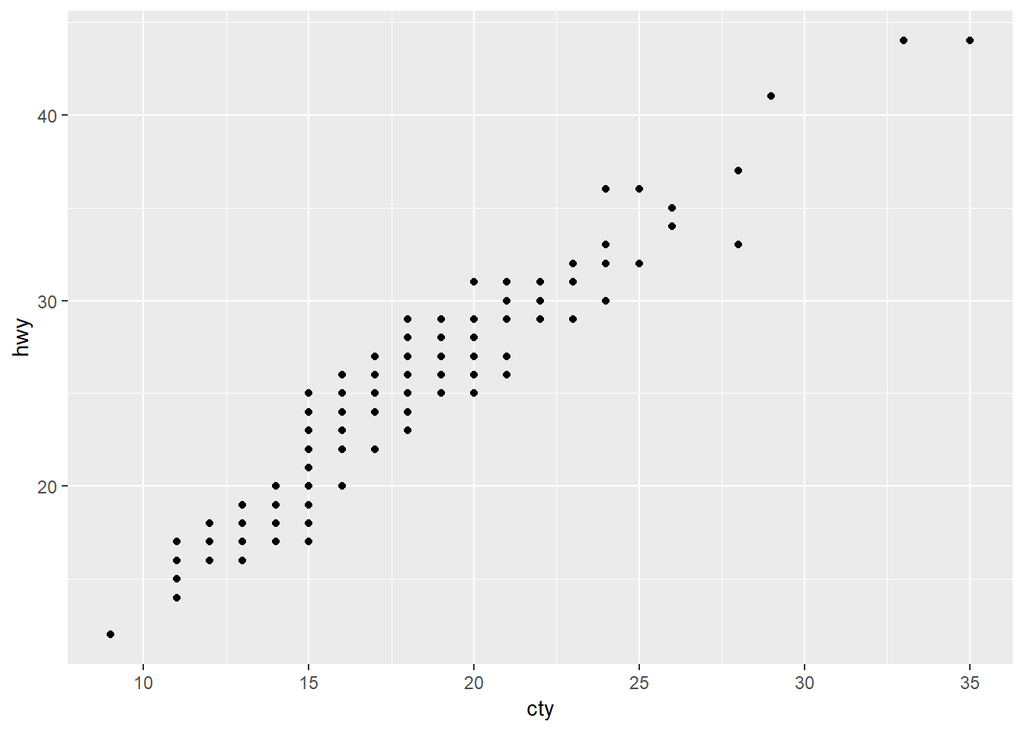

```r
#plot a scatter between cty and hwy.
ggplot(mpg,aes(cty,hwy)) +
  geom_point()
```

The relationship looks like a linear one. With increaseing values for cty we get greater values for hwy as well.

2. What does ggplot(mpg, aes(model, manufacturer)) + geom_point() show? Is it useful? How could you modify the data to make it more informative?

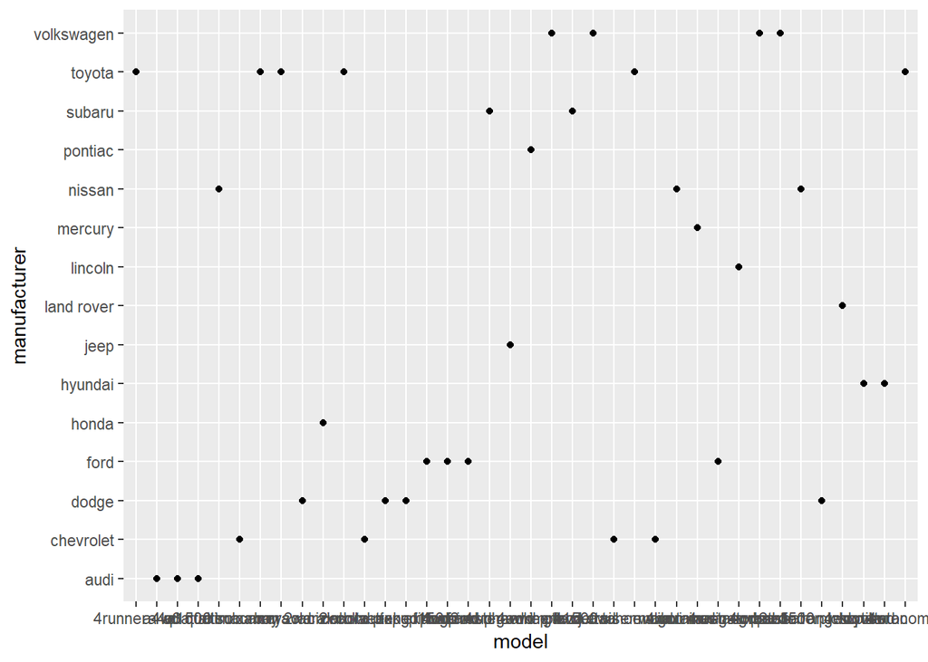

```r
ggplot(mpg,aes(model,manufacturer)) +
  geom_point()
```

it would be better if we could rotate the x axis able to make them visible and not overlap.

3. Describe the data, aesthetic mappings and layers used for each of the following plots. You’ll need to guess a little because you haven’t seen all the datasets and functions yet, but use your common sense! See if you can predict what the plot will look like before running the code. 1: ggplot(mpg, aes(cty, hwy)) + geom_point() 2: ggplot(diamonds, aes(carat, price)) + geom_point() 3: ggplot(economics, aes(date, unemploy)) + geom_line() 4: ggplot(mpg, aes(cty)) + geom_histogram()

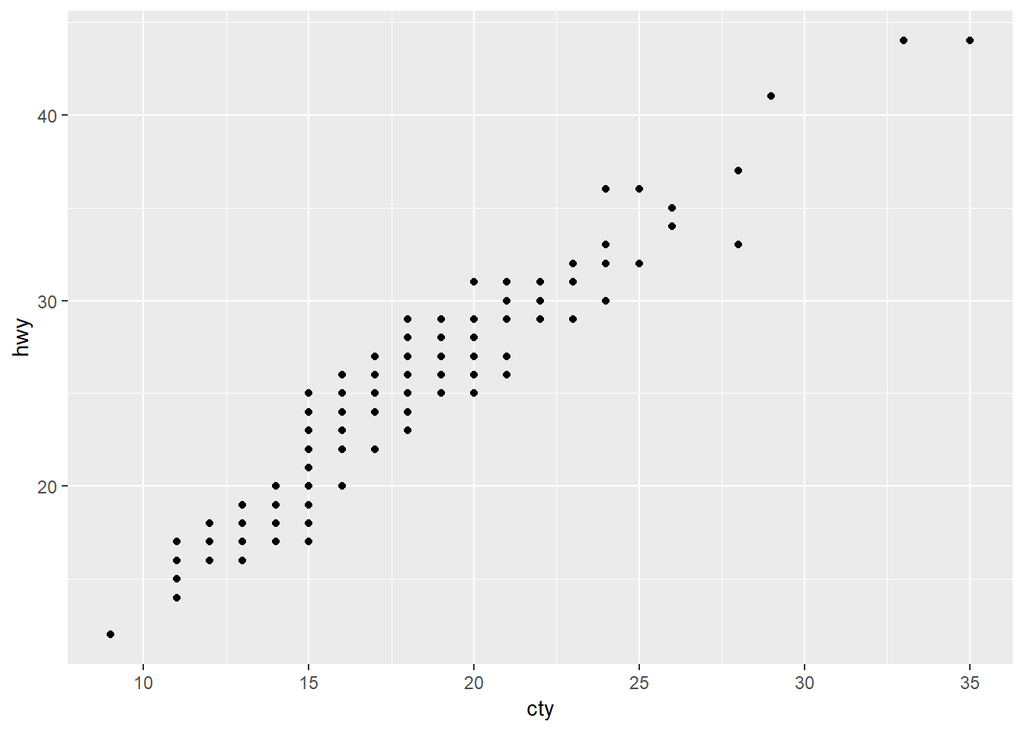

```r
#scatter plot for x=cty and y=hwy
ggplot(mpg,aes(cty,hwy)) +
  geom_point()
```